# gobike_slide_deck slides

## (San Francisco Bay "Ford GoBike" system)

### By (Richard Achiak)

## Investigation Overview

This data set includes information about individual rides made in a bike-sharing system covering the greater San Francisco Bay area in 2019. In this investigation, I looked at the characteristics of users based on time of the day and day of the week in which most trips are done, how long was the average trip and find out if these results depend on a user type of this services (Customer and Substcribers) as well as members gender.

## Dataset Overview

After the dataset was assesed, it was noticed that the dataset contains 183,412 rows and 16 columns.

Wth the following variables;

- Trip Duration (seconds)
- Start Time and Date
- End Time and Date
- Start Station ID
- Start Station Name
- Start Station Latitude
- Start Station Longitude
- End Station ID
- End Station Name
- End Station Latitude
- End Station Longitude
- Bike ID
- User Type (Subscriber or Customer – “Subscriber” = Member or “Customer” = Casual)
- Member birth year
- Member gender
- Bike share for all trips

## Percentage by user type

The following plot is looking at the user composition of the ford gobike system, they were categorize as customers and subscribers.

- As it is seen from the followin chart, most trips representing 90.5% were taken by subscribers with the remaining 9.5% being just casual riders. This shows how subscribers are making efficient use of thier subscription.

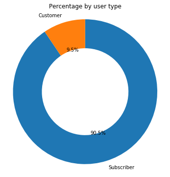

## Percentages of trips made in terms of time of the day

The following pie chart seeks to know the percentage of users who use the ford gobike system at various times, this was put into three categories morning, afternoon and evening.

- It was that most trips were done at morning (00:00 - 11:59 hours) representing 38.5%, followed closely by afternoon (12:00 - 17:59 hours) representing 38.3%. Night had 23.2% of all users which is reasonable.

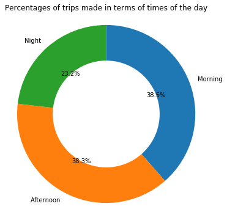

## Total count of users on each day of the week

The following chart shows the number of users of the ford gobike system for each day of the week. From monday to sunday.

- Most trip were done on midweek which is Thursday as was observed, this was followed by Tuesday and wednesday respectively. Weekends seem the list patronage of this service.

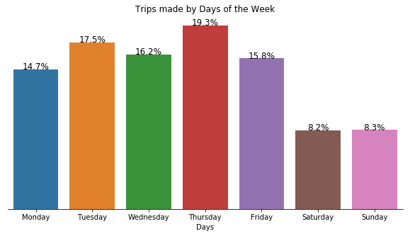

## Percentage count of each Age group

Ages were put into groups of 8 classes, this basically looks at the age group that patronize the gobike services more.

- It was found that, mojority of the gobike users were between the ages of 21 to 40 years respectively as these age groups constitute almost 80% of all users.

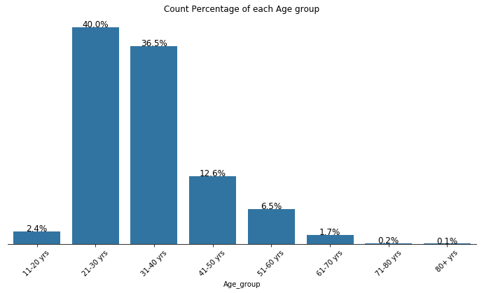

## Percentage by user gender

Of male, female and other as stated in the dataset, which of these gender patronize the services of ford gobike system?

- Male riders were more than 3 times that of female riders as seen in the plot following, males represent 74.6% of the trips made entire period and females represent only 23.3% while other had a share of 2.1%.

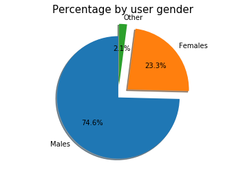

## Age distribution among member gender as well as among user type

I also seek to find the distribution of age among variables such as member and user type.

- All member gender having almost the same average age and containing a number of outliers.
- The same average age for both subscribers and customers

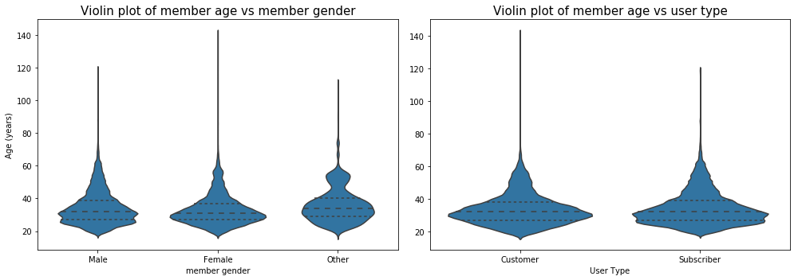